# Longitudinal Analysis

Janette Avelar

2023-03-22

#How many schools participated in both SY2021-22 and SY2022-23?

73 schools from last year (2021-22) participated this year (2022-23). This accounts for about 30% of all schools that responded this year. The full list of schools is displayed in the table below.

```r
#pull in all datasets with school IDs and names first
merge_2019 <- import(here("data", "previous_datasets", "schools_2018-19.csv")) %>%
  select(school_id, school_name) %>%
  mutate(year = rep("2018-19", 173))
merge_2021a <- import(here("data", "previous_datasets", "schools_2020-21a.csv")) %>%
  select(school_id, school_name) %>%
  mutate(year = rep("2020-21", 144))
merge_2021b <- import(here("data", "previous_datasets", "schools_2020-21b.csv")) %>%
  select(school_id, school_name) %>%
  mutate(year = rep("2020-21", 88))
merge_2021c <- import(here("data", "previous_datasets", "schools_2020-21c.csv")) %>%
  select(school_id, school_name) %>%
  mutate(year = rep("2020-21", 99))
merge_2022 <- import(here("data", "previous_datasets", "schools_2021-22.csv")) %>%
  select(school_id, school_name) %>%
  mutate(year = rep("2021-22", 161))
merge_2023 <- dat %>%
  select(school_id, school_name) %>%
  mutate(year = rep("2022-23", 251))
#merge last year and this year
repeat_schls_2023 <- merge_2023 %>%
  left_join(merge_2022, by = c("school_id", "school_name")) %>%
  filter(!is.na(year.y)) %>%
  select(!c(year.x, year.y)) %>%
  rename(`School ID` = school_id,
         `School Name` = school_name)
#table
datatable(repeat_schls_2023)
```

|  | School ID | School Name |
| --- | --- | --- |
| 1 | 628 | Rainier Valley Leadership Academy |
| 2 | 627 | Phoenix International Academy |
| 3 | 622 | Georgia Fugees Academy Charter School |
| 4 | 620 | Atlas Public Schools |
| 5 | 615 | Oceti Sakowin Educational Learning Center |
| 6 | 608 | Legacy Classical Christian Academy |
| 7 | 604 | The 1881 Institute |
| 8 | 588 | Texas Tech University K-12 |
| 9 | 587 | Asu Preparatory Academy Digital |
| 10 | 569 | The Sycamore School |

[output cut: 63 more lines]

#How many schools participated in SY2020-21, SY2021-22, and SY2022-23?

There are 41 schools that have participated every year since AY2021-21. That’s 7.5% of all schools we’ve had participate over time (N = 542). The list of schools is displayed in the table below.

```r
recent_schls <- merge_2021a %>%
  #start by merging other 2021 datasets with a full merge to create full set
  full_join(merge_2021b, by = c("school_id", "school_name", "year")) %>%
  full_join(merge_2021c, by = c("school_id", "school_name", "year")) %>%
  #get rid of repeat schools
  unique() %>%
  #left join following year to find crossover
  left_join(merge_2022, by = c("school_id", "school_name")) %>%
  filter(!is.na(year.y)) %>%
  left_join(merge_2023, by = c("school_id", "school_name")) %>%
  filter(!is.na(year)) %>%
  select(!starts_with("year")) %>%
  rename(`School ID` = school_id,
         `School Name` = school_name)
#table
datatable(recent_schls)
```

|  | School ID | School Name |
| --- | --- | --- |
| 1 | 8 | Anastasis Academy |
| 2 | 44 | Common Ground High School |
| 3 | 47 | Concourse Village Elementary School |
| 4 | 52 | DB EXCEL (Kingsport) |
| 5 | 70 | Evergreen Community Charter School |
| 6 | 71 | Fannie Lou Hamer Freedom High School |
| 7 | 85 | Girls Athletic Leadership Middle School |
| 8 | 105 | Juab High School |
| 9 | 122 | Map Academy Charter School |
| 10 | 139 | New Legacy Charter School |

[output cut: 31 more lines]

#How many schools have participated across years?

We have a total of 542 Canopy schools, and their participation over time is displayed in the table below by year.

**Hint** If you want to sort by multiple rows, select 1 column followed by the next column you’d like to sort. If you select all 4 columns, it will display the 21 schools that have participated since the start of Canopy at the top of the table.

```r
long_schls <- merge_2019 %>%
  full_join(merge_2021a, by = c("school_id", "school_name", "year")) %>%
  full_join(merge_2021b, by = c("school_id", "school_name", "year")) %>%
  full_join(merge_2021c, by = c("school_id", "school_name", "year")) %>%
  full_join(merge_2022, by = c("school_id", "school_name", "year")) %>%
  full_join(merge_2023, by = c("school_id", "school_name", "year")) %>%
  mutate(wave = rep("Participated", length(817))) %>%
  pivot_wider(names_from = year,
              values_from = wave) %>%
  select(!school_id) %>%
  rename(`School Name` = school_name)
datatable(long_schls)
```

|  | School Name | 2018-19 | 2020-21 | 2021-22 | 2022-23 |
| --- | --- | --- | --- | --- | --- |
| 1 | A2 Virtual + Academy | Participated | Participated |  |  |
| 2 | The Academy of Advanced Learning | Participated | Participated |  | Participated |
| 3 | Albemarle Road Elementary School | Participated |  |  |  |
| 4 | Amana Academy | Participated |  |  |  |
| 5 | American Academy of Innovation | Participated |  |  |  |
| 6 | Anastasis Academy | Participated | Participated | Participated | Participated |
| 7 | Armada High School | Participated | Participated |  |  |
| 8 | Aspen Academy | Participated | Participated | Participated |  |
| 9 | Avalon School | Participated | Participated |  | Participated |
| 10 | Avanti High School | Participated |  | Participated |  |

[output cut: 532 more lines]

#What practices are being adopted or retired over time?

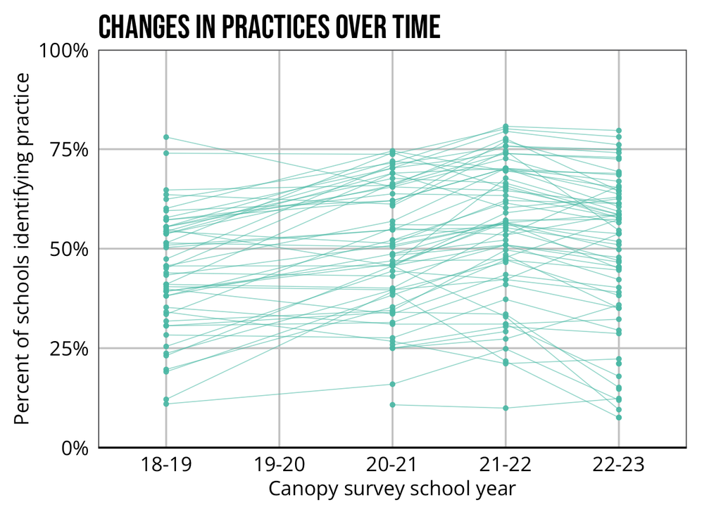

```r
#load all data
canopy_old <- readRDS(here("data", "canopy-2019-2021.rds"))
dat_22 <- readRDS(here("data", "canopy-2022.rds")) %>%
  mutate(year = rep(2022, nrow(.)))
xwalk = read_csv(here("data/SY2022-23 Tags.csv"), show_col_types = FALSE) %>%
  select(tag = `2022-23 Variable name`, tag_21_22 = `2021-22 equivalent`, tag_20_21 = `2020-21 equivalent`, tag_18_19 = `2018-19 equivalent`)
#look at all schools all years
#create full list of tags across years
all_tags = unique(na.omit(unlist(xwalk)))
#rename this one tag? not sure why
canopy_old = canopy_old %>%
  mutate(expanded_success = coalesce(expanded_success, redefining_success)) %>%
  select(-redefining_success)
#figure out which names need renaming
rn_18_19 = which(xwalk$tag_18_19 %in% names(canopy_old))
rn_20_21 = which(xwalk$tag_20_21 %in% names(canopy_old))
rn_21_22 = which(xwalk$tag_21_22 %in% names(dat_22))
#rename AY21-22 data
dat_22 = dat_22 %>%
  select(year, school_id, any_of(all_tags)) %>%
  rename(setNames(xwalk[["tag_21_22"]][rn_21_22], xwalk[["tag"]][rn_21_22]))
#rename AY20-21 data
canopy_old = canopy_old %>%
  select(year, school_id, any_of(all_tags)) %>%
  rename(setNames(xwalk[["tag_20_21"]][rn_20_21], xwalk[["tag"]][rn_20_21]))
#rename AT 18-19 data
# canopy_old = canopy_old %>%
#   rename(setNames(xwalk[["tag_18_19"]][rn_18_19], xwalk[["tag"]][rn_18_19]))
#convert all to character
canopy_old = canopy_old %>% mutate(across(everything(), as.character))
dat_22 = dat_22 %>% mutate(across(everything(), as.character))
#combine datasets
over_time = tags %>%
  select(school_id, starts_with("practices")) %>%
  mutate(year = "2023", school_id = as.character(school_id)) %>%
  select(school_id, year, any_of(all_tags)) %>%
  mutate(across(everything(), as.character)) %>%
  bind_rows(canopy_old, dat_22)
#convert school year names
sy_all = c("18-19", "19-20", "20-21", "21-22", "22-23")
over_time %>%
  mutate(
    sy = case_when(
      year == "2019" ~ "18-19",
      year %in% c("2020", "2021") ~ "20-21",
      year == "2022" ~ "21-22",
      year == "2023" ~ "22-23"
    ),
    sy = factor(sy, levels = sy_all),
    sy_i = as.integer(sy) - 1
    # setting levels here accounts for the missing school year in the spacing.
  ) -> over_time

if((over_time %>%
  group_by(school_id, sy) %>%
  filter(n() > 1) %>%
  nrow) > 0) stop("duplicates introduced!")

over_time %>%
  pivot_longer(cols = starts_with("practice"), names_to = "tag") %>%
  mutate(flag = case_when(is.na(value) | value == "0" ~ 0L, TRUE ~ 1L)) %>%
  group_by(sy) %>%
  mutate(n_sch_year = n_distinct(school_id)) %>%
  group_by(sy, sy_i, tag) %>%
  summarize(pct_practicing = mean(flag), n_sch_year = first(n_sch_year), .groups = "drop") %>%
  filter(pct_practicing > 0) ->
  long

#create plot 1
ggplot(long, aes(x = sy, y = pct_practicing, group = tag)) +
  geom_line(alpha = 0.6, color = transcend_cols[2], size = 0.3) +
  geom_point(alpha = 0.9, color = transcend_cols[2], size = 1.2) +
  bar_y_scale_percent +
  scale_x_discrete(drop = FALSE) +
  labs(
    y = "Percent of schools identifying practice",
    x = "Canopy survey school year",
    title = "Changes in practices over time"
  )
```

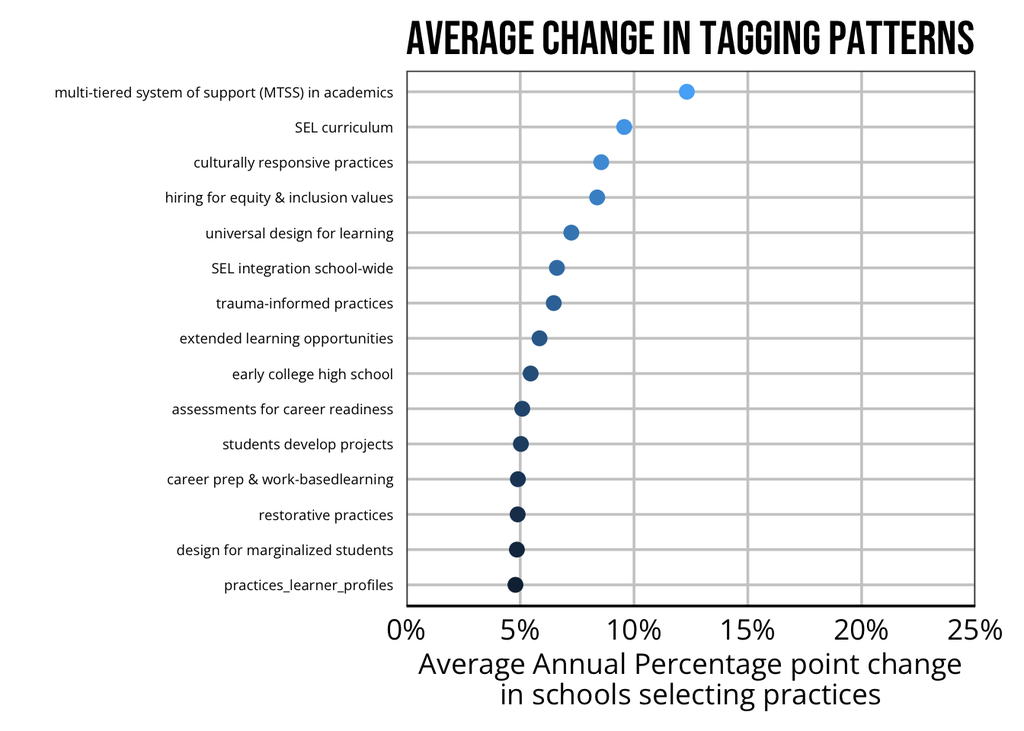

```r
#convert to long file for changes over time plot 2
long %>%
  group_by(tag) %>%
  nest() %>%
  mutate(
    models = lapply(data, \(df) tidy(lm(pct_practicing ~ sy_i, data = df, weights = n_sch_year)))
  ) -> mods

mods %>%
  unnest(models) %>%
  filter(term == "sy_i") ->
  coefs

coefs %>%
  ungroup %>%
  filter(!is.na(estimate)) %>%
  mutate(rank = rank((-estimate))) %>%
  arrange(rank) %>%
  mutate(tag = reorder(factor(tag), estimate)) -> coefs

#plot 2
tag_change <-
coefs %>% slice(1:15) %>%
  ggplot(aes(y = tag, x = estimate)) +
  geom_point(aes(color = rank), size = 3) +
  scale_color_continuous(guide = "none", trans = "reverse") +
  scale_y_discrete(labels = label_tags()) +
  scale_x_continuous(labels = scales::label_percent(accuracy = 1), limits = c(0, .25), expand = expansion()) +
  labs(
    x = "Average Annual Percentage point change\nin schools selecting practices",
    y = "",
    title = "Average change in tagging patterns"
  ) +
  theme(axis.text.y = element_text(size = rel(0.5)))
tag_change
```

```r
# ggsave("finding-22.png", plot = tag_change, path = here("final_products", "draft-findings"),
#        width = 12, height = 8, units = "in")
```

#How many tags have been retained across years?